# FoodHub_Project_Okesola_Moses_Olusola

**FoodHub Project**

Data Analysis By Okesola Moses Olusola

**Problem Statement**

**Description**

**Context**

The number of restaurants in New York is increasing day by day. Lots of students and busy professionals rely on those restaurants due to their hectic lifestyles. Online food delivery service is a great option for them. It provides them with good food from their favorite restaurants. A food aggregator company FoodHub offers access to multiple restaurants through a single smartphone app.

The app allows the restaurants to receive a direct online order from a customer. The app assigns a delivery person from the company to pick up the order after it is confirmed by the restaurant.

The delivery person then uses the map to reach the restaurant and waits for the food package. Once the food package is handed over to the delivery person, he/she confirms the pick-up in the app and travels to the customer's location to deliver the food. The delivery person confirms the drop-off in the app after delivering the food package to the customer.

The customer can rate the order in the app. The food aggregator earns money by collecting a fixed margin of the delivery order from the restaurants.

**Objective**

The food aggregator company has stored the data of the different orders made by the registered customers in their online portal. They want to analyze the data to get a fair idea about the demand of different restaurants which will help them in enhancing their customer experience.

Suppose you are hired as a Data Scientist in this company and the Data Science team has shared some of the key questions that need to be answered. Perform the data analysis to find answers to these questions that will help the company to improve the business.

**FoodHub Data Description**

The data contains the different data related to a food order. The detailed data dictionary is given below.

Data Dictionary order_id: Unique ID of the order

customer_id: ID of the customer who ordered the food

restaurant_name: Name of the restaurant

cuisine_type: Cuisine ordered by the customer

cost: Cost of the order

day_of_the_week: Indicates whether the order is placed on a weekday or weekend (The weekday is from Monday to Friday and the weekend is Saturday and Sunday)

rating: Rating given by the customer out of 5 food_preparation_time: Time (in minutes) taken by the restaurant to prepare the food.

delivery_time: Time (in minutes) taken by the delivery person to deliver the food package.

**Importing the necessary libraries**

```python
# Libraries that help with reading and manipulating data
import numpy as np
import pandas as pd
```

```python
# Libraries that help with data visualization
import matplotlib.pyplot as plt
import seaborn as sns
```

```python
# Command to tell python to display the graphs or plots
%matplotlib inline
```

**Loading the FoodHub Dataset**

```python
FoodHub_data = pd.read_csv('/content/drive/MyDrive/foodhub_order.csv')
```

**Overview of the FoodHub Dataset**

```python
# The first five rows of the dataset- This is to check if the dataset is properly loaded
FoodHub_data.head()
```

|  | order_id | customer_id | restaurant_name | cuisine_type | cost_of_the_order | day_of_the_week | rating | food_preparation_time | delivery_time |
| --- | --- | --- | --- | --- | --- | --- | --- | --- | --- |
| 0 | 1477147 | 337525 | Hangawi | Korean | 30.75 | Weekend | Not given | 25 | 20 |
| 1 | 1477685 | 358141 | Blue Ribbon Sushi Izakaya | Japanese | 12.08 | Weekend | Not given | 25 | 23 |
| 2 | 1477070 | 66393 | Cafe Habana | Mexican | 12.23 | Weekday | 5 | 23 | 28 |
| 3 | 1477334 | 106968 | Blue Ribbon Fried Chicken | American | 29.20 | Weekend | 3 | 25 | 15 |
| 4 | 1478249 | 76942 | Dirty Bird to Go | American | 11.59 | Weekday | 4 | 25 | 24 |

- The dataset contains information about the order placed by each customer at a particular restaurant.
- It contains details about the types of food or cuisine orders and its cost.
- The time a customer orders, the time it takes to prepare the food order ,and when it was delivered to the customer are all given in the dataset.
- The day of the week the order was placed, and how each customer rated the restraurant services are captured.

**The number of rows and columns in the dataset** (**Question 1**)

```python
# Understanding the shape of the dataset
FoodHub_data.shape
```

```
(1898, 9)
```

There are 1898 rows and 9 columns in the dataset.

```python
# extract the list of columns in the dataset
FoodHub_data. columns
```

```
Index(['order_id', 'customer_id', 'restaurant_name', 'cuisine_type',
       'cost_of_the_order', 'day_of_the_week', 'rating',
       'food_preparation_time', 'delivery_time'],
      dtype='object')
```

**The datatypes of different columns in the data set** (**Question 2**)

```python
# Checking the data types of the columns for the dataset
FoodHub_data.info()
```

```
<class 'pandas.core.frame.DataFrame'>
RangeIndex: 1898 entries, 0 to 1897
Data columns (total 9 columns):
 #   Column                 Non-Null Count  Dtype
---  ------                 --------------  -----
 0   order_id               1898 non-null   int64
 1   customer_id            1898 non-null   int64
 2   restaurant_name        1898 non-null   object
 3   cuisine_type           1898 non-null   object
 4   cost_of_the_order      1898 non-null   float64
 5   day_of_the_week        1898 non-null   object
 6   rating                 1898 non-null   object
 7   food_preparation_time  1898 non-null   int64
 8   delivery_time          1898 non-null   int64
dtypes: float64(1), int64(4), object(4)
memory usage: 133.6+ KB
```

- There are 5 numerical columns in the data and 4 object type columns.
- We observed that order_id and customer_id are read as integer type columns instead of unique identifiers.
- All the columns have their entries complete.

**Checking for missing values in the data** (**Question 3**)

```python
# Checking for missing values in the data
FoodHub_data. isnull().sum()
```

```
order_id                 0
customer_id              0
restaurant_name          0
cuisine_type             0
cost_of_the_order        0
day_of_the_week          0
rating                   0
food_preparation_time    0
delivery_time            0
dtype: int64
```

There are no missing values in the FoodHub dataset.

**Statistical summary of the dataset**

What is the minimum, average, and maximum time it takes for the food to be prepared once an order is placed (**Question 4**)

```python
# Getting the statistical summary for the dataset
FoodHub_data.describe()
```

|  | order_id | customer_id | cost_of_the_order | food_preparation_time | delivery_time |
| --- | --- | --- | --- | --- | --- |
| count | 1.898000e+03 | 1898.000000 | 1898.000000 | 1898.000000 | 1898.000000 |
| mean | 1.477496e+06 | 171168.478398 | 16.498851 | 27.371970 | 24.161749 |
| std | 5.480497e+02 | 113698.139743 | 7.483812 | 4.632481 | 4.972637 |
| min | 1.476547e+06 | 1311.000000 | 4.470000 | 20.000000 | 15.000000 |
| 25% | 1.477021e+06 | 77787.750000 | 12.080000 | 23.000000 | 20.000000 |
| 50% | 1.477496e+06 | 128600.000000 | 14.140000 | 27.000000 | 25.000000 |
| 75% | 1.477970e+06 | 270525.000000 | 22.297500 | 31.000000 | 28.000000 |
| max | 1.478444e+06 | 405334.000000 | 35.410000 | 35.000000 | 33.000000 |

**Other statiistical analysis observations**

- The descriptive statistical analysis gave us average value of the unique identifiers: order_id and customer_id which are not suppose to be so.
- The average value of three numerical variables namely cost_of_the_order, food_preparation_time, and delivery_time are 16.5 dollars, 27 minutes, and 24 minutes respectively.
- The range of cost_of_the_order is from 4.5(minimun order cost) to 35(maximum order cost)dollars.
- The range of food_preparation_time is from 20 (minimum time for food preparation) to 35 (maximum time for food preparation) minutes.
- The range of delivery_time is from 15 (minimum time for food delivery) to 33(maximum time for food delivery) minutes.
- The median of cost_of_the_order, food_preparation_time, and delivery_time are 14 dollars, 27 minutes, and 25 minutes respectively.
- The standard deviation which is the measure of the spread of data around the average value is low for cost_of_the_order, food_preparation_time, and delivery_time. The tightness of data around the mean is pronounced in food_preparation_time, and delivery_time.

**The order_id and customer_id are unique identifiers. Let us change them to categorical columns**

```python
FoodHub_data['order_id'] = FoodHub_data['order_id'].astype('category')
FoodHub_data['customer_id'] = FoodHub_data['customer_id'].astype('category')
print(FoodHub_data.dtypes)
```

```
order_id                 category
customer_id              category
restaurant_name            object
cuisine_type               object
cost_of_the_order         float64
day_of_the_week            object
rating                     object
food_preparation_time       int64
delivery_time               int64
dtype: object
```

```python
# Checking the data types of the columns for the dataset
# after changing order_id and customer_id to categorical columns
FoodHub_data.info()
```

```
<class 'pandas.core.frame.DataFrame'>
RangeIndex: 1898 entries, 0 to 1897
Data columns (total 9 columns):
 #   Column                 Non-Null Count  Dtype
---  ------                 --------------  -----
 0   order_id               1898 non-null   category
 1   customer_id            1898 non-null   category
 2   restaurant_name        1898 non-null   object
 3   cuisine_type           1898 non-null   object
 4   cost_of_the_order      1898 non-null   float64
 5   day_of_the_week        1898 non-null   object
 6   rating                 1898 non-null   object
 7   food_preparation_time  1898 non-null   int64
 8   delivery_time          1898 non-null   int64
dtypes: category(2), float64(1), int64(2), object(4)
memory usage: 232.4+ KB
```

```python
# Getting the statistical summary for the dataset after a change in order_id and customer_id to categorical columns
FoodHub_data.describe()
```

|  | cost_of_the_order | food_preparation_time | delivery_time |
| --- | --- | --- | --- |
| count | 1898.000000 | 1898.000000 | 1898.000000 |
| mean | 16.498851 | 27.371970 | 24.161749 |
| std | 7.483812 | 4.632481 | 4.972637 |
| min | 4.470000 | 20.000000 | 15.000000 |
| 25% | 12.080000 | 23.000000 | 20.000000 |
| 50% | 14.140000 | 27.000000 | 25.000000 |
| 75% | 22.297500 | 31.000000 | 28.000000 |
| max | 35.410000 | 35.000000 | 33.000000 |

*Find how many orders are not rated* (**Question 5**)

```python
# Find the count of orders that were not rated
not_rated_count = (FoodHub_data['rating'] == 'Not given').sum()
print("Number of orders not rated:", not_rated_count)
```

```
Number of orders not rated: 736
```

- 736 orders are not rated.
- The rating for each order not rated is designated by 'Not given' in the rating column.

```python
# Count the occurrences of each unique value in the 'rating' column
rating_counts = FoodHub_data['rating'].value_counts()

# Get the count of orders that were not rated
not_rated_count = rating_counts.get('Not given', 0)

print("Number of orders not rated:", not_rated_count)
```

```
Number of orders not rated: 736
```

**FoodHub Exploratory Data Analysis (EDA)**

**Univariate Analysis of numerical variables** (**Question 6**)

**Cuisine Type**

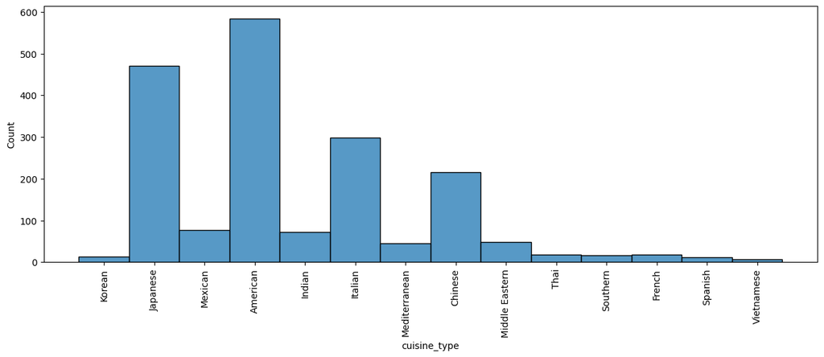

```python
# Creating a histogram plot for Cuisine type
plt.figure(figsize = (15,5))
sns.histplot(data =FoodHub_data, x = 'cuisine_type');
plt.xticks(rotation =90);
```

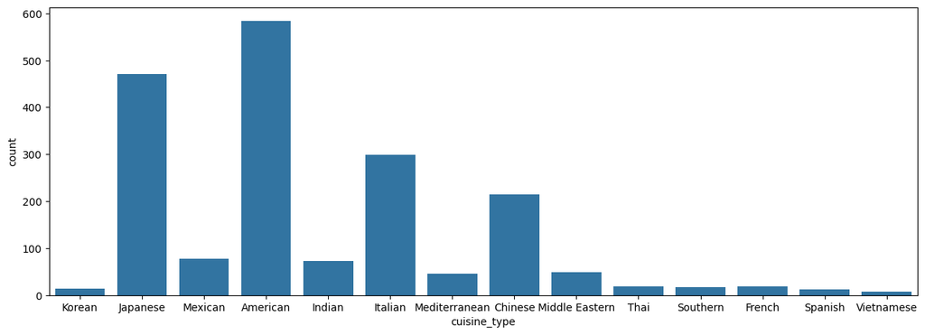

```python
# Creating a countplot for Cuisine type
plt.figure(figsize = (15,5))
sns.countplot(data =FoodHub_data, x = 'cuisine_type');
```

- American cuisine has the highest order.
- Vietnamese cuisine has the lowest order.

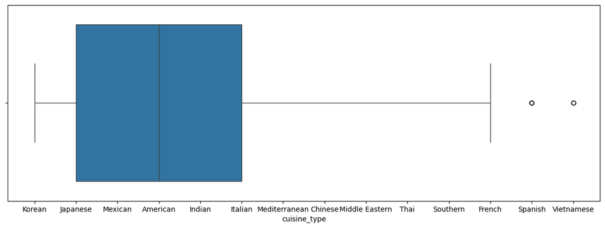

```python
# Creating a boxplot for Cuisine type
plt.figure(figsize = (15,5))
sns.boxplot(data =FoodHub_data, x = 'cuisine_type');
```

**Cost of the Order**

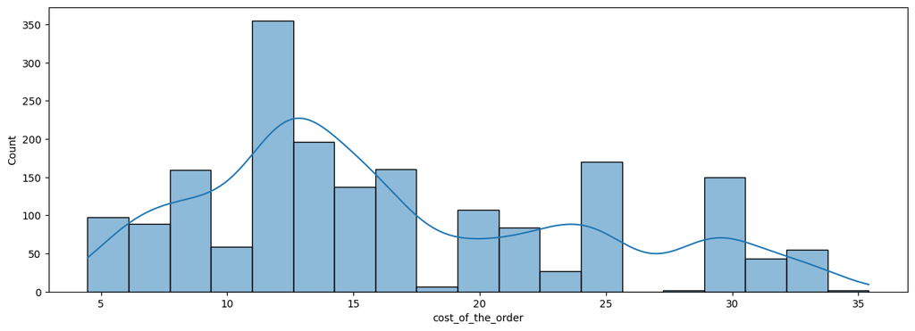

```python
# Histogram for the cost of order
plt.figure(figsize = (15,5))
sns.histplot(data=FoodHub_data,x='cost_of_the_order', kde = True)
plt.show()
```

[figure not shown]

```python
# Countplot for the cost of order
sns.countplot(data=FoodHub_data,x='cost_of_the_order')
plt.show()
```

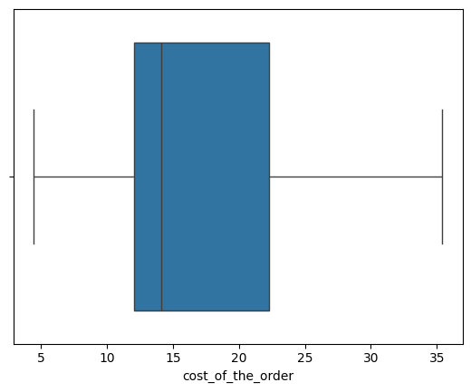

```python
# Boxplot for the cost of order
sns.boxplot(data=FoodHub_data,x='cost_of_the_order')
plt.show()
```

- Cost of the order is rightly skewed.
- The minimum cost of order is 5 dollars, and its maximum is 35 dollars.
- The median of the cost of the order is slightly above 14 dollars.

**Day of the Week**

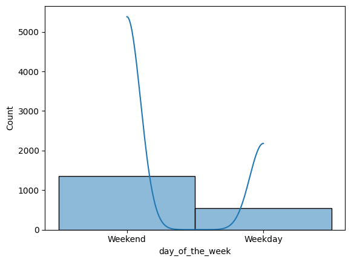

```python
# Histogram for the day of the week
sns.histplot(data=FoodHub_data,x='day_of_the_week', kde=True)
plt.show()
```

The demand of customers for cuisine food is very high during weekends than weekdays.

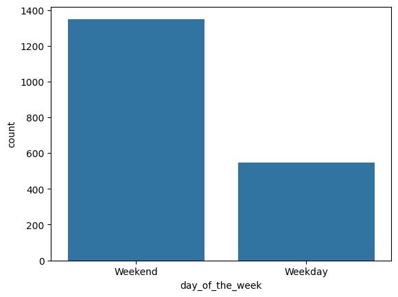

```python
# Countplot for the day of the week
sns.countplot(data=FoodHub_data,x='day_of_the_week')
plt.show()
```

**Rating**

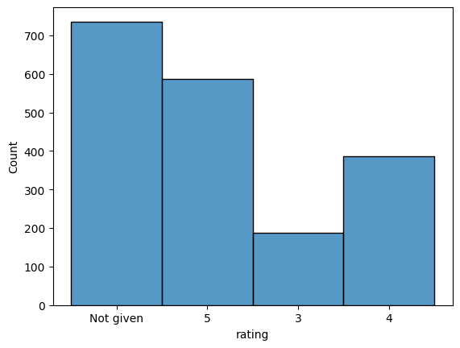

```python
# Histogram for the rating
sns.histplot(data=FoodHub_data,x='rating')
plt.show()
```

- 'Not given' rating is about 39% of the rating column and it occurs most.
- Rating 5, Rating 4, and Rating 3 account for about 31%, 20%,and 10% of the total rating respectively.

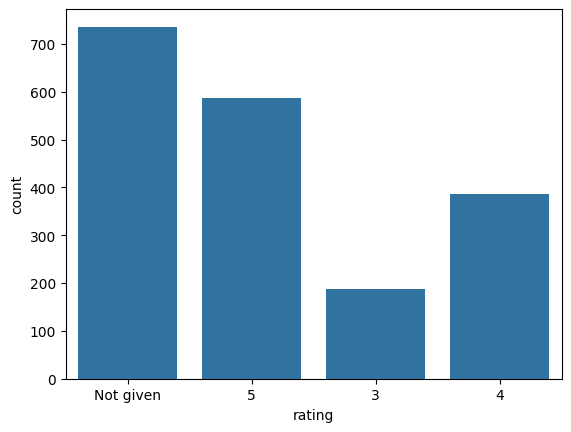

```python
# Countplot for the rating
sns.countplot(data=FoodHub_data,x='rating')
plt.show()
```

- 'Not given'rating is about 39% of the rating column and it occurs most.
- Rating 5, Rating 4, and Rating 3 account for about 31%, 20%, and 10% of the total rating respectively.

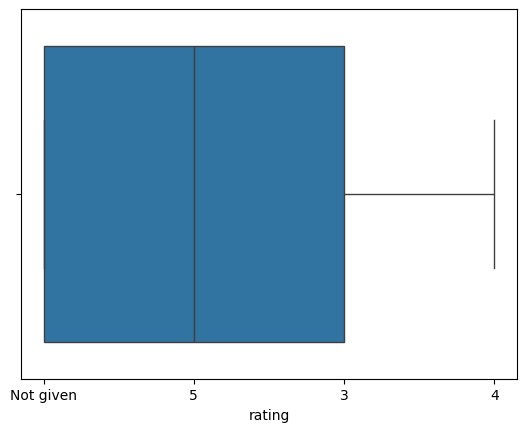

```python
# Boxplot for the rating
sns.boxplot(data=FoodHub_data,x='rating')
plt.show()
```